# APLICAÇÃO - REGRESSÃO LOGÍSTICA ORDINAL

Shelda Ramos e Emily Mendonça

2023-11-17

```r
library(foreign)
```

```r
library(ggplot2)
library(MASS)
```

### Este documento não é um relatório formal, aqui estão apenas os códigos de aplicação e algumas interpretações.

# EXEMPLO DE APLICAÇÃO

### Conjunto de dados hipotéticos contendo uma variável de 3 níveis (“apply”). Os níveis “improvável”, “um pouco provável” e “muito provável” são referentes a decisão de se candidatar a uma pós-graduação. Também há informações sobre a escolaridade dos pais, se a instituição de graduação é pública ou privada e as notas de performance (“gpa”) do aluno. Portanto, essa aplicação deseja verificar os fatores que influenciam na decisão de se inscrever em uma pós-graduação.

# OBJETIVO

### Ajustar um modelo de regressão logística ordinal com as variáveis citadas.

```r
dat <- read.dta("https://stats.idre.ucla.edu/stat/data/ologit.dta")
head(dat)
```

```
##             apply pared public  gpa
## 1     very likely     0      0 3.26
## 2 somewhat likely     1      0 3.21
## 3        unlikely     1      1 3.94
## 4 somewhat likely     0      0 2.81
## 5 somewhat likely     0      0 2.53
## 6        unlikely     0      1 2.59
```

```r
str(dat)
```

```
## 'data.frame':    400 obs. of  4 variables:
##  $ apply : Factor w/ 3 levels "unlikely","somewhat likely",..: 3 2 1 2 2 1 2 2 1 2 ...
##  $ pared : int  0 1 1 0 0 0 0 0 0 1 ...
##  $ public: int  0 0 1 0 0 1 0 0 0 0 ...
##  $ gpa   : num  3.26 3.21 3.94 2.81 2.53 ...
##  - attr(*, "datalabel")= chr ""
##  - attr(*, "time.stamp")= chr " 3 Aug 2010 10:45"
##  - attr(*, "formats")= chr [1:4] "%15.0g" "%9.0g" "%9.0g" "%9.0g"
##  - attr(*, "types")= int [1:4] 251 251 251 254
##  - attr(*, "val.labels")= chr [1:4] "apply" "" "" ""
##  - attr(*, "var.labels")= chr [1:4] "" "" "" ""
##  - attr(*, "version")= int 12
##  - attr(*, "label.table")=List of 1
##   ..$ apply: Named int [1:3] 0 1 2
##   .. ..- attr(*, "names")= chr [1:3] "unlikely" "somewhat likely" "very likely"
```

### Estatísticas Descritivas

```r
lapply(dat[, c("apply", "pared", "public")], table)
```

```
## $apply
##
##        unlikely somewhat likely     very likely
##             220             140              40
##
## $pared
##
##   0   1
## 337  63
##
## $public
##
##   0   1
## 343  57
```

```r
 ftable(xtabs(~ public + apply + pared, data = dat))
```

```
##                        pared   0   1
## public apply
## 0      unlikely              175  14
##        somewhat likely        98  26
##        very likely            20  10
## 1      unlikely               25   6
##        somewhat likely        12   4
##        very likely             7   3
```

### Em média, o gpa dos alunos é de 2,999.

```r
summary(dat$gpa)
```

```
##    Min. 1st Qu.  Median    Mean 3rd Qu.    Max.
##   1.900   2.720   2.990   2.999   3.270   4.000
```

```r
sd(dat$gpa)
```

```
## [1] 0.3979409
```

### Ajuste do modelo de regressão logística ordinal

### Vale ressaltar que o modelo de regressão logística traz os resultados estimadores na forma logarítmica, mas para uma melhor interpretação, usaremos a exponenciação da variável.

```r
modelo <- polr(apply ~ pared + public + gpa, data = dat, Hess = TRUE)
summary(modelo)
```

```
## Call:
## polr(formula = apply ~ pared + public + gpa, data = dat, Hess = TRUE)
##
## Coefficients:
##           Value Std. Error t value
## pared   1.04769     0.2658  3.9418
## public -0.05879     0.2979 -0.1974
## gpa     0.61594     0.2606  2.3632
##
## Intercepts:
##                             Value   Std. Error t value
## unlikely|somewhat likely     2.2039  0.7795     2.8272
## somewhat likely|very likely  4.2994  0.8043     5.3453
##
## Residual Deviance: 717.0249
## AIC: 727.0249
```

### Odds

```r
exp(coef(modelo))
```

```
##     pared    public       gpa
## 2.8510579 0.9429088 1.8513972
```

### Convertendo os coeficientes em odds ratio. Para obter o OR e os intervalos de confiança, apenas exponenciamos as estimativas e os intervalos de confiança.

```r
exp(cbind(OR = coef(modelo), confint(modelo)))
```

```
##               OR     2.5 %   97.5 %
## pared  2.8510579 1.6958376 4.817114
## public 0.9429088 0.5208954 1.680579
## gpa    1.8513972 1.1136247 3.098490
```

### OR significa a razão de chances.

### Para alunos cujos pais possuem pós-graduação a chance de serem mais prováveis de se inscreverem em uma pós-graduação é 2,85 vezes maior do que dos alunos cujo os pais não possuem pós-graduação.

### Em relação a variável GPA, para cada variação unitária na variável GPA, aumenta em 1,85 as chances do aluno ser mais provável de se inscrever em uma pós graduação.

### Agora em relação a instituição ser pública ou privada, utilizando a fórmula a seguir, temos um valor de aproximadamente 5,71%.

```r
((1-0.9429088)*100) #public
```

```
## [1] 5.70912
```

### Portanto, para alunos de escola pública, as chances de serem mais prováveis de concordar em se inscrever em uma pós graduação é 5,71% menor que dos alunos de escola privada.

### Gráficos

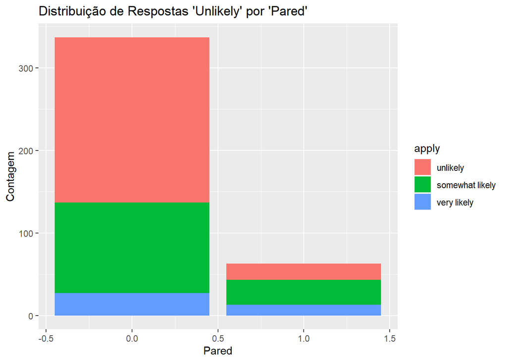

```r
# Carregue a biblioteca ggplot2
library(ggplot2)

# Crie um gráfico de barras empilhadas para respostas "unlikely" e variável pared
ggplot(dat, aes(x = pared, fill = apply)) +
  geom_bar(position = "stack", stat = "count") +
  labs(title = "Distribuição de Respostas 'Unlikely' por 'Pared'",
       x = "Pared",
       y = "Contagem")
```

### Referências

#### Ordinal Logistic Regression | R Data Analysis Examples. Disponível em: https://stats.oarc.ucla.edu/r/dae/ordinal-logistic-regression/.